# 第三层议程设置

Chris Chao Su, Lei Guo, Hsuan-Ting Chen

1/22/2021

## 第三层议程设置的数据建立和假设检验。

此处的实例操作以Chen, Guo & Su (2020)发表于 Journal of Communication的文章为例，来说明如何使用媒体和个人问卷数据，利用R来建立议程之间的关系矩阵，然后使用二次指派回归程序（MRQAP）来分析矩阵之间的关系，从而回答第三层议程设置的研究假设。

在此过程中，我们使用了多个R包，用于数据处理、建立矩阵、计算回归程序的统计显著性等。

### 步骤一：数据读取

接下来我们要看看研究中主要使用的两种不同类型的数据。

第一种数据是媒体数据，涵盖了香港的主要新闻媒体机构，根据媒体的政治倾向不一，可以大致划分为三类：建制派新闻媒体、泛民派新闻媒体、以及中立的新闻媒体。在获取了每一条新闻数据之后，我们接着对每一条新闻内容进行编码，如果该条新闻所报道的内容有涉及到某一个具体的议题，那么我们就以数字“1”记录，没有涉及到的议题则不做记录。

利用SPSS，我们可以进一步将数据转换成在R中更为方便的类型，也就是说，将没有涉及到的议题全部以数字“0”记录，以方便接下来我们运算属性网络矩阵。

编码后的新闻数据我们在SPSS中预处理后，以sav的各式储存，并读入到R中，这里我们直接使用预处理好的新闻媒介数据“media_final.sav”。对每一条新闻数据，我们有以下编码：新闻媒体机构（Q2），媒体的政治倾向（Media_party），每一条新闻内容的独特编号（Q3），以及十六个议题的编码结果（Issue1 ~ Issue16）。在Media_party这一变量中，1 = “泛民派新闻媒体”，2 = “中立新闻媒体”，3 = “建制派新闻媒体”。

```r
Media_final <- haven::read_sav("Media_final.sav")

head(Media_final)
```

```
## # A tibble: 6 x 19
##   Q2    Media_party Q3    Issue1 Issue2 Issue3 Issue4 Issue5 Issue6 Issue7
##   <chr>   <dbl+lbl> <chr>  <dbl>  <dbl>  <dbl>  <dbl>  <dbl>  <dbl>  <dbl>
## 1 TVB   3 [Pro-Est… TVB10      1      0      0      1      0      0      0
## 2 TVB   3 [Pro-Est… TVB1…      0      0      1      1      0      0      0
## 3 TVB   3 [Pro-Est… TVB1…      0      0      0      1      0      0      0
## 4 TVB   3 [Pro-Est… TVB1…      0      0      0      1      1      0      0
## 5 TVB   3 [Pro-Est… TVB1…      0      0      1      1      0      0      0
## 6 TVB   3 [Pro-Est… TVB1…      0      0      0      1      0      0      0
## # … with 9 more variables: Issue8 <dbl>, Issue9 <dbl>, Issue10 <dbl>,
## #   Issue11 <dbl>, Issue12 <dbl>, Issue13 <dbl>, Issue14 <dbl>, Issue15 <dbl>,
## #   Issue16 <dbl>
```

同样地，我们可以将数据读入到R中：

```r
survey_all <- haven::read_sav("survey_all.sav")

head(survey_all)
```

```
## # A tibble: 6 x 17
##   respid partisan self_1_R self_2_R self_3_R self_4_R self_5_R     q12_1
##    <dbl> <dbl+lb> <dbl+lb> <dbl+lb> <dbl+lb> <dbl+lb> <dbl+lb> <dbl+lbl>
## 1      2 2 [Neut…  3 [Dem… 8 [Hong…  8 [Hon…  0 [Non… NA        84
## 2      3 1 [Demo… 10 [Inf… 3 [Demo… 15 [Soc… 12 [Leg…  0 [Non…  20
## 3      4 2 [Neut… 10 [Inf… 3 [Demo… 10 [Inf… 11 [Law] 14 [One…  87
## 4      6 1 [Demo… 12 [Leg… 3 [Demo… 13 [Mai…  4 [Eco…  0 [Non… 999 [999…
## 5      8 2 [Neut… 10 [Inf… 3 [Demo…  0 [Non… NA       NA        69
## 6      9 2 [Neut… 10 [Inf… 3 [Demo…  3 [Dem…  0 [Non… NA        75
## # … with 9 more variables: q13_1 <dbl+lbl>, q14_1 <dbl+lbl>, q15_1 <dbl+lbl>,
## #   q16_1 <dbl+lbl>, q17_1 <dbl+lbl>, q18_1 <dbl+lbl>, q19_1 <dbl+lbl>,
## #   q20_1 <dbl+lbl>, q21_1 <dbl+lbl>
```

### 步骤二：媒体关联网络矩阵

首先我们将数据根据新闻媒体的政治立场进行细分。

```r
Media_democ <- Media_final[which(Media_final$Media_party==1),] # 泛民派新闻媒体
Media_neutr <- Media_final[which(Media_final$Media_party==2),] # 中立新闻媒体
Media_proes <- Media_final[which(Media_final$Media_party==3),] # 建制派新闻媒体
```

接下来我们就可以针对每一种政治类型的媒介数据来运算其属性网络矩阵。

首先是泛民派新闻媒体，选取其16个议题的编码内容，转换成矩阵格式，计算倒置矩阵，再通过倒置矩阵与原矩阵相乘的方式得到16*16的属性网络矩阵。

```r
Media_democ <- Media_democ %>% select(Issue1:Issue16) #选取议题的编码内容
Media_democ <- as.matrix(Media_democ) # 转换为矩阵格式
Media_democ_T <- t(Media_democ) # 计算倒置矩阵
Media_democ_matrix <- Media_democ_T %*% Media_democ # 计算属性网络矩阵
Media_democ_matrix
```

```
##         Issue1 Issue2 Issue3 Issue4 Issue5 Issue6 Issue7 Issue8 Issue9 Issue10
## Issue1      95      7     47     12     21      3      0      6      0      44
## Issue2       7     22     15      3      7      1      0      5      0       7
## Issue3      47     15    207     19     22      3      3      8      0      33
## Issue4      12      3     19     85      4      6      2      5      0       9
## Issue5      21      7     22      4     37      2      0      3      0      18
## Issue6       3      1      3      6      2     13      0      4      0       0
## Issue7       0      0      3      2      0      0      4      0      0       1
## Issue8       6      5      8      5      3      4      0     22      0       6
## Issue9       0      0      0      0      0      0      0      0      0       0
## Issue10     44      7     33      9     18      0      1      6      0      81
## Issue11     22      3     35      5     10      2      0      2      0      21
## Issue12     51     11     43     15     23      6      2     11      0      46
## Issue13      1      0      4      1      1      0      0      0      0       1
## Issue14      0      0      1      0      0      0      0      0      0       0
## Issue15      1      0      5      5      0      0      0      1      0       4
## Issue16     15      4     67      5      5      1      0      1      0      13
##         Issue11 Issue12 Issue13 Issue14 Issue15 Issue16
## Issue1       22      51       1       0       1      15
## Issue2        3      11       0       0       0       4
## Issue3       35      43       4       1       5      67
## Issue4        5      15       1       0       5       5
## Issue5       10      23       1       0       0       5
## Issue6        2       6       0       0       0       1
## Issue7        0       2       0       0       0       0
## Issue8        2      11       0       0       1       1
## Issue9        0       0       0       0       0       0
## Issue10      21      46       1       0       4      13
## Issue11      62      23       5       1       8       6
## Issue12      23      97       0       1       1      20
## Issue13       5       0       7       0       1       1
## Issue14       1       1       0       3       1       2
## Issue15       8       1       1       1      18       2
## Issue16       6      20       1       2       2     100
```

然后为了方便之后的MRQAP程序，我们对矩阵的数据类型和议题/属性的表头进行修正，并且将所以对角线数据（即议题与自己之间的关系）全部设置为0。其中Issue_names_R是一个议题与议题编号之间的对应表格。

```r
Media_democ_matrix <- Media_democ_matrix %>% as.matrix
diag(Media_democ_matrix) <- 0

Issue_names_R <- read_excel("Issue_names_R.xlsx")
Issue_names_R # 议题与议题编号之间的对应表格
```

```
## # A tibble: 16 x 2
##       ID Issues
##    <dbl> <chr>
##  1     1 Culture/Self-identify
##  2     2 Democracy
##  3     3 Hong Kong Politics
##  4     4 Economy
##  5     5 Education
##  6     6 History
##  7     7 Hong Kong Independence
##  8     8 Human Rights
##  9     9 Infrastructure
## 10    10 Law
## 11    11 Mainland Politics
## 12    12 Population Mobility
## 13    13 Housing
## 14    14 Social Movement
## 15    15 Social Welfare
## 16    16 Technology
```

```r
colnames(Media_democ_matrix) <- Issue_names_R$Issues[1:16] # 对属性网络重新命名
rownames(Media_democ_matrix) <- Issue_names_R$Issues[1:16] # 对属性网络重新命名
```

最后，可以看到属性网络矩阵的最后数据形式和内容：

```r
Media_democ_matrix[1:5,1:5] # 在这里我们只展示前五行和前五列的数据
```

```
##                       Culture/Self-identify Democracy Hong Kong Politics
## Culture/Self-identify                     0         7                 47
## Democracy                                 7         0                 15
## Hong Kong Politics                       47        15                  0
## Economy                                  12         3                 19
## Education                                21         7                 22
##                       Economy Education
## Culture/Self-identify      12        21
## Democracy                   3         7
## Hong Kong Politics         19        22
## Economy                     0         4
## Education                   4         0
```

接着我们可以以同样的方式计算中立媒体以及建制派新闻媒体16*16的属性网络矩阵。

```r
# 中立媒体的议程关系矩阵

Media_neutr <- Media_neutr %>% select(Issue1:Issue16)

Media_neutr <- as.matrix(Media_neutr)
Media_neutr_T <- t(Media_neutr)
Media_neutr_matrix <- Media_neutr_T %*% Media_neutr

Media_neutr_matrix <- Media_neutr_matrix %>% as.matrix
diag(Media_neutr_matrix) <- 0
colnames(Media_neutr_matrix) <- Issue_names_R$Issues[1:16]
rownames(Media_neutr_matrix) <- Issue_names_R$Issues[1:16]
```

```r
# 建制派媒体的议程关系矩阵

Media_proes <- Media_proes %>% select(Issue1:Issue16)

Media_proes <- as.matrix(Media_proes)
Media_proes_T <- t(Media_proes)
Media_proes_matrix <- Media_proes_T %*% Media_proes

Media_proes_matrix <- Media_proes_matrix %>% as.matrix
diag(Media_proes_matrix) <- 0

colnames(Media_proes_matrix) <- Issue_names_R$Issues[1:16]
rownames(Media_proes_matrix) <- Issue_names_R$Issues[1:16]
```

### 步骤三：公众关联网络矩阵（认知属性网络）

公众关联网络矩阵的建立则与媒体矩阵稍有不同，主要差别在于，我们需要考虑到每个受访者所回答的议题关联强度。因此，我们需要首先对所有可能的出现的议题建立对应关系，然后与问卷中与每一对议题的关联强度进行一一映射，最后还要将每一对议题之间（pairs of every two given issues) 的总关系强度进行整合。

同样地，我们将公众问卷数据根据受访者的政治倾向进行细分，并为每一种政治倾向的受访者群体建立新的子数据：

```r
Democratic <-survey_all[ which (survey_all$partisan==1),] # 泛民派支持者
Centrists <-survey_all[ which (survey_all$partisan==2),] # 政治中立者
Establish <-survey_all[ which (survey_all$partisan==3),] # 建制派支持者
```

以泛民支持者的认知属性网络为例。我们首先需要选取五个属性变量（self_1_R ～ self_5_R）以及十个属性间关系变量（q12_1 ～ q12_1），并对缺省值和无关联值（999）进预处理。

```r
# 选取属性变量
D_self_issues <- Democratic %>% select(respid, self_1_R,self_2_R, self_3_R, self_4_R, self_5_R)
D_self_issues[is.na(D_self_issues)] <- 0

# 选取属性关系变量
D_self_weights <- Democratic %>% select(respid, q12_1:q21_1)
D_self_weights[D_self_weights == 999] <- 0
D_self_weights[is.na(D_self_weights)] <- 0
```

然后对数据中的每一对属性（a pair of issues）建立一种关系结构，并按照属性标号进行排序。

```r
# 建立每一对属性之间的关系结构
D_self = data.frame()
for (i in 1: length(dimnames(D_self_issues)[[1]])) {
  v = unlist(D_self_issues[i, 2:6])
  v = t(combn(v,2))
  D_self = rbind(D_self, v)
}
D_self <- t(apply(D_self,1,sort)) %>% as.data.frame() # 在这里，属性之间的关系是无方向的
```

将属性之间的关系强度值映射到上叙属性关系结构中

```r
# 增加属性之间的关系强度值（weights）
D_self_w = c()
for (i in 1: length(dimnames(D_self_weights)[[1]])) {
  w = unlist(D_self_weights[i, 2:11])
  w = t(combn(w,1))
  D_self_w = append(D_self_w,w)
}
D_self$weight <- D_self_w

D_self <- D_self[!D_self$V1 %in% c(0), ] # 移除所有的无关系属性对
D_self <- aggregate(weight~V1+V2, data = D_self, FUN = sum) # 整合同属性对之间的关系强度
```

建立认知属性矩阵：

```r
D_self_matrix <- AdjacencyFromEdgelist(D_self, check.full = TRUE) %>% as.data.frame()
D_self_matrix <- D_self_matrix[1:16, 1:16]
D_self_matrix
```

```
##    adjacency.1 adjacency.2 adjacency.3 adjacency.4 adjacency.5 adjacency.6
## 1         1581         276        2074        2027         702         100
## 2            0           0         889         909         222          50
## 3            0           0        4044        2667         578          62
## 4            0           0           0         758         427         100
## 5            0           0           0           0         161           0
## 6            0           0           0           0           0           0
## 7            0           0           0           0           0           0
## 8            0           0           0           0           0           0
## 9            0           0           0           0           0           0
## 10           0           0           0           0           0           0
## 11           0           0           0           0           0           0
## 12           0           0           0           0           0           0
## 13           0           0           0           0           0           0
## 14           0           0           0           0           0           0
```

[output cut: 36 more lines]

对认知属性矩阵进行重命名和调整：

```r
colnames(D_self_matrix) <- Issue_names_R$Issues
rownames(D_self_matrix) <- Issue_names_R$Issues

D_self_matrix <- D_self_matrix %>% as.matrix
diag(D_self_matrix) <- 0 # 去除属性自身之间的强度值
lowerTriangle(D_self_matrix) <- upperTriangle(D_self_matrix, byrow = TRUE) #生成整体矩阵

head(D_self_matrix)
```

```
##                       Culture/Self-identify Democracy Hong Kong Politics
## Culture/Self-identify                     0       276               2074
## Democracy                               276         0                889
## Hong Kong Politics                     2074       889                  0
## Economy                                2027       909               2667
## Education                               702       222                578
## History                                 100        50                 62
##                       Economy Education History Hong Kong Independence
## Culture/Self-identify    2027       702     100                    439
## Democracy                 909       222      50                    161
## Hong Kong Politics       2667       578      62                   1126
## Economy                     0       427     100                    532
## Education                 427         0       0                      0
## History                   100         0       0                      0
##                       Human Rights Infrastructure  Law Mainland Politics
## Culture/Self-identify          595            448 1565                76
## Democracy                      885            198  430                61
## Hong Kong Politics            1468           2319 8937               258
## Economy                        572            633 1142               323
## Education                      265            116 1179                 0
## History                        100             30  155                 0
##                       Population Mobility Housing Social Movement
## Culture/Self-identify                2413     741             169
## Democracy                             234     240             253
## Hong Kong Politics                   4533     714             433
## Economy                              1399     908               0
## Education                            1636     753             465
## History                                 0       0              77
##                       Social Welfare Technology
## Culture/Self-identify           1706          0
## Democracy                        404          0
## Hong Kong Politics               943          0
## Economy                         1755          0
## Education                       1084        100
## History                            0          0
```

以相同的方式，我们可以建立建制派支持者的认知属性网络：

```r
# 选取属性变量
E_self_issues <- Establish %>% select(respid, self_1_R,self_2_R, self_3_R, self_4_R, self_5_R)
E_self_issues[is.na(E_self_issues)] <- 0

# 选取属性关系变量
E_self_weights <- Establish %>% select(respid, q12_1:q21_1)
E_self_weights[E_self_weights == 999] <- 0
E_self_weights[is.na(E_self_weights)] <- 0

# 建立每一对属性之间的关系结构
E_self = data.frame()
for (i in 1: length(dimnames(E_self_issues)[[1]])) {
  v = unlist(E_self_issues[i, 2:6])
  v = t(combn(v,2))
  E_self = rbind(E_self, v)
}
E_self <- t(apply(E_self,1,sort)) %>% as.data.frame()

# 增加属性之间的关系强度值（weights）
E_self_w = c()
for (i in 1: length(dimnames(E_self_weights)[[1]])) {
  w = unlist(E_self_weights[i, 2:11])
  w = t(combn(w,1))
  E_self_w = append(E_self_w,w)
}
E_self$weight <- E_self_w

E_self <- E_self[!E_self$V1 %in% c(0), ]
E_self <- aggregate(weight~V1+V2, data = E_self, FUN = sum)

# 建立认知属性矩阵
E_self_matrix <- AdjacencyFromEdgelist(E_self, check.full = TRUE) %>% as.data.frame()
E_self_matrix <- E_self_matrix[1:16, 1:16]

# 对认知属性矩阵进行重命名和调整
colnames(E_self_matrix) <- Issue_names_R$Issues
rownames(E_self_matrix) <- Issue_names_R$Issues
# Adjusting final matrix
E_self_matrix <- E_self_matrix %>% as.matrix
diag(E_self_matrix) <- 0
lowerTriangle(E_self_matrix) <- upperTriangle(E_self_matrix, byrow = TRUE)
```

### 步骤四：研究假设验证（MRQAP）

在此，我们使用MRQAP对新闻媒体的属性网络和公众的认知属性网络之关联性进行分析，并验证以下两个研究假设： * 假设一：香港建制派新闻媒体的属性网络和建制派支持者的认知属性网络存在显著关联。 * 假设二：香港泛民派新闻媒体的属性网络和泛民派支持者的认知属性网络存在显著关联。

在这里我们使用的R包是“asnipe”，实际上也可以使用sna包中的netlm函数

验证假设一：

```r
proesfit <- mrqap.dsp(E_self_matrix ~ Media_proes_matrix + Media_democ_matrix + Media_neutr_matrix, intercept = TRUE, directed = "undirected", diagonal = FALSE, test.statistic = "t-value", tol = 1e-07, randomisations = 1000)

proesfit
```

```
## MRQAP with Double-Semi-Partialing (DSP)
##
## Formula:  E_self_matrix ~ Media_proes_matrix + Media_democ_matrix + Media_neutr_matrix
##
## Coefficients:
##                    Estimate   P(β>=r) P(β<=r) P(|β|<=|r|)
## intercept          155.768884 0.985   0.015   0.015
## Media_proes_matrix   7.199072 0.960   0.040   0.035
## Media_democ_matrix   3.513382 0.109   0.891   0.224
## Media_neutr_matrix  28.487194 1.000   0.000   0.001
##
## Residual standard error: 322.8 on 116 degrees of freedom
## F-statistic: 11.63 on 3 and 116 degrees of freedom, p-value: 1.015e-06
## Multiple R-squared: 0.2312   Adjusted R-squared: 0.2154
## AIC: -254.8725
```

验证假设二：

```r
democfit <- mrqap.dsp(D_self_matrix ~ Media_proes_matrix + Media_democ_matrix + Media_neutr_matrix, intercept = TRUE, directed = "undirected",  diagonal = FALSE, test.statistic = "t-value", tol = 1e-07, randomisations = 1000)

democfit
```

[output not shown]

### 步骤五：可视化

这里我们用建制派媒体的关系可视化为例（此处使用R包igraph，也可以使用sna包进行可视化）：

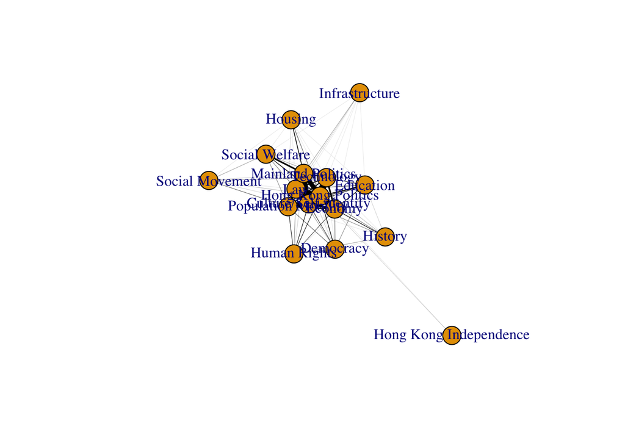

```r
plot <- graph_from_adjacency_matrix(Media_proes_matrix, mode = c("undirected"), weighted = TRUE, diag = FALSE,add.rownames = TRUE)
plot.igraph(plot,vertex.label=V(plot)$name,layout=layout.fruchterman.reingold,edge.color="black",edge.width=E(plot)$weight*.05)
```